# LeNet-Lab-Solution

Self-Driving Car Engineer Nanodegree Deep Learning Project: Build a Traffic Sign Recognition Classifier

In this notebook, a template is provided for you to implement your functionality in stages, which is required to successfully complete this project. If additional code is required that cannot be included in the notebook, be sure that the Python code is successfully imported and included in your submission if necessary.

[output not shown]

In addition to implementing code, there is a writeup to complete. The writeup should be completed in a separate file, which can be either a markdown file or a pdf document. There is a write up template that can be used to guide the writing process. Completing the code template and writeup template will cover all of the rubric points for this project.

The rubric contains "Stand Out Suggestions" for enhancing the project beyond the minimum requirements. The stand out suggestions are optional. If you decide to pursue the "stand out suggestions", you can include the code in this Ipython notebook and also discuss the results in the writeup file.

```
Note: Code and Markdown cells can be executed using the Shift + Enter keyboard shortcut. In addition, Markdown cells can be edited by typically double-clicking the cell to enter edit mode.
```

## Load Data

```python
# Load pickled data
import pickle
import numpy as np

# TODO: Fill this in based on where you saved the training and testing data

datadir = "traffic-signs-data"
# datadir = "helio_data"

training_file = datadir + "/train.p"
validation_file= datadir + "/valid.p"
testing_file = datadir + "/test.p"

with open(training_file, mode='rb') as f:
    train = pickle.load(f)
with open(validation_file, mode='rb') as f:
    valid = pickle.load(f)
with open(testing_file, mode='rb') as f:
    test = pickle.load(f)

X_train, y_train = train['features'], train['labels']
X_validation, y_validation = valid['features'], valid['labels']
X_test, y_test = test['features'], test['labels']

### Replace each question mark with the appropriate value.

# TODO: Number of training examples
n_train = len(y_train)

# TODO: Number of testing examples.
n_test = len(y_test)

# TODO: Number of validation examples.
n_valid = len(y_validation)

# TODO: What's the shape of an traffic sign image?
image_shape = image_shape = X_train.shape

# TODO: How many unique classes/labels there are in the dataset.
n_classes = len(np.unique(y_train))

img_size=X_train.shape[1] #Size of input images

print("Number of training examples =", n_train)
print("Number of testing examples =", n_test)
print("Number of validation examples =", n_valid)
print("Image data shape =", image_shape)
print("Number of classes =", n_classes)
```

```
Number of training examples = 34799
Number of testing examples = 12630
Number of validation examples = 4410
Image data shape = (34799, 32, 32, 3)
Number of classes = 43
```

The MNIST data that TensorFlow pre-loads comes as 28x28x1 images.

However, the LeNet architecture only accepts 32x32xC images, where C is the number of color channels.

You do not need to modify this section.

## Visualize Data

View a sample from the dataset.

You do not need to modify this section.

```python
import random
import numpy as np
import matplotlib.pyplot as plt
%matplotlib inline

index = random.randint(0, len(X_train))
image = X_train[index].squeeze()

plt.figure(figsize=(1,1))
plt.imshow(image)
print(y_train[index])
```

[output not shown]

```
7
```

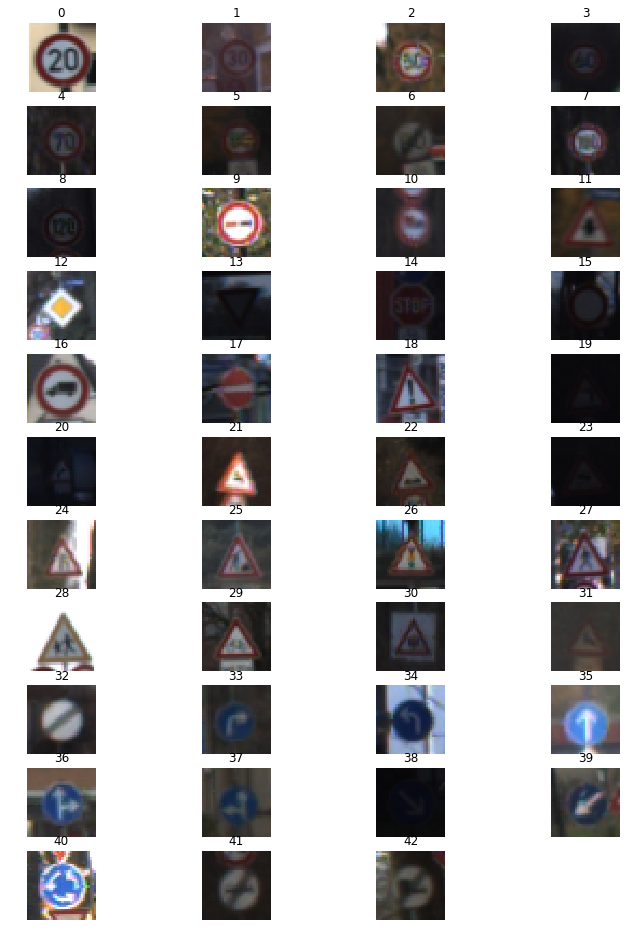

```python
### Data exploration visualization goes here.
### Feel free to use as many code cells as needed.
# Visualizations will be shown in the notebook.

def plot_labels(X_data, y_data):
    %matplotlib inline

    num_of_samples=[]
    plt.figure(figsize=(12, 16.5))
    for i in range(0, n_classes):
        plt.subplot(11, 4, i+1)
        x_selected = X_data[y_data == i]
    #     print(len(x_selected))
        plt.imshow(x_selected[0, :, :, :]) #to draw the first image in each label/class
        plt.title(i)
        plt.axis('off')
        num_of_samples.append(len(x_selected))
    plt.show()

    #Plot number of images per class
#     plt.figure(figsize=(12, 4))
#     plt.bar(range(0, n_classes), num_of_samples)
#     plt.title("Distribution of the training dataset")
#     plt.xlabel("Class/Label")
#     plt.ylabel("No of images")
#     plt.show()

#     print("Min number of images per class =", min(num_of_samples))
#     print("Max number of images per class =", max(num_of_samples))

plot_labels(X_train, y_train)
```

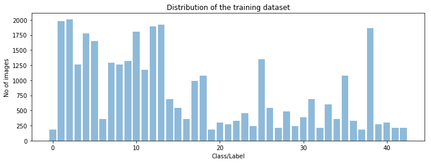

```python
import random
from collections import Counter
import numpy as np
import matplotlib.pyplot as plt
%matplotlib inline
def show_dist(y_data):
    l = len(set(y_data))
    values = Counter(y_data).values()
    keys = Counter(y_data).keys()
    # print(values)
    # print(keys)
    # plt.show()
    # plt.pie([float(v) for v in values], labels=[float(k) for k in keys],
    #            autopct=None)
    # plt.show()
    plt.figure(figsize=(12, 4))
    plt.bar([float(k) for k in keys], [float(v) for v in values], align='center', alpha=0.5)
    plt.title("Distribution of the training dataset")
    plt.xlabel("Class/Label")
    plt.ylabel("No of images")
    plt.show()

show_dist(y_train)
```

```python
# Convert to grayscale
X_train_rgb = X_train
X_train_gry = np.sum(X_train/3, axis=3, keepdims=True)

X_validation_rgb = X_validation
X_validation_gry = np.sum(X_validation/3, axis=3, keepdims=True)

X_test_rgb = X_test
X_test_gry = np.sum(X_test/3, axis=3, keepdims=True)

print('RGB shape:', X_train_rgb.shape)
print('Grayscale Train shape:', X_train_gry.shape)

print('Grayscale Validation shape:', X_validation_gry.shape)

print('Grayscale Test shape:', X_test_gry.shape)
```

```
RGB shape: (34799, 32, 32, 3)
Grayscale Train shape: (34799, 32, 32, 1)
Grayscale Validation shape: (4410, 32, 32, 1)
Grayscale Test shape: (12630, 32, 32, 1)
```

```python
print(np.mean(X_train_gry))
print(np.mean(X_validation_gry))
print(np.mean(X_test_gry))
```

```
82.677589037
83.5564273756
82.1484603612
```

```python
# Normalize (-1 to 1)  --- not used
X_train_gry_normalized = (X_train_gry - 128)/128
X_test_gry_normalized = (X_test_gry - 128)/128
# X_validation_gry_normalized = (X_validation_gry - 128)/128

print(np.mean(X_train_gry_normalized))
print(np.mean(X_test_gry_normalized))
# print(np.mean(X_validation_gry_normalized))
```

```
-0.354081335648
-0.358215153428
```

```
Number of extended training examples = 86430
Shape (86430, 32, 32, 1)
```

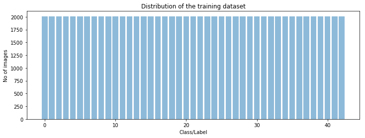

```python
# Smoothen out the distribution by extending the data

import cv2
import numpy as np

def rotate_img(img):
    center_x,center_y = int(img.shape[0]/2), int(img.shape[1]/2)
    ang = 30.0*np.random.rand()-15
    matrix = cv2.getRotationMatrix2D((center_x, center_y), ang, 1.0)
#     print(img.shape[:2])
    img = cv2.warpAffine(img, matrix, img.shape[:2])
    img = img[:,:,np.newaxis]
#     print(img.shape)
    return img




def extend_data(X_data, y_data):
    samples_per_class = np.bincount(y_data)
# print("Samples per class is ", samples_per_class)
    max_samples = max(samples_per_class)
# print("Max Samples ", max_samples)
    rotated_images = []
    rotated_labels = []
    for i in range(0, n_classes):
        x_selected = X_data[y_data == i]    # get all images for a label/class
        l = len(x_selected)                  # get no of such images
        diff = max_samples -l                 # get diff with max
        if diff > 0:
    #         print(i, "--", len(x_selected))
            if diff < l:
                for j in range(0, diff):                      # loop over the diff to rotate image
                    rotated_img = rotate_img(x_selected[j, :, :, :])
    #                 print(rotated_img.shape)
                    rotated_images.append(rotated_img)
                    rotated_labels.append(i)
            else:
                dvmd = divmod(diff, l)
                for m in range(0,dvmd[0]):
                    for j in range(0, l):
                        rotated_img = rotate_img(x_selected[j, :, :, :])
                        rotated_images.append(rotated_img)
                        rotated_labels.append(i)
                if dvmd[1] > 0:
                    for n in range(0,dvmd[1]):
                        rotated_img = rotate_img(x_selected[j, :, :, :])
                        rotated_images.append(rotated_img)
                        rotated_labels.append(i)

    X_extended = np.append(X_data, rotated_images, axis=0)

    y_extended = np.append(y_data, rotated_labels, axis=0)

    return X_extended, y_extended



X_train_extended, y_train_extended = extend_data(X_train_gry, y_train)

n_train_extended = len(y_train_extended)
print("Number of extended training examples =", n_train_extended)
print("Shape", X_train_extended.shape)

show_dist(y_train_extended)
```

```python
# min and max of train data
min = X_train_extended[:,:,0].min()
max = X_train_extended[:,:,0].max()
print("min of extended data is: ", min)
print("max of extended data is: ", max)
```

```
min of extended data is:  0.0
max of extended data is:  255.0
```

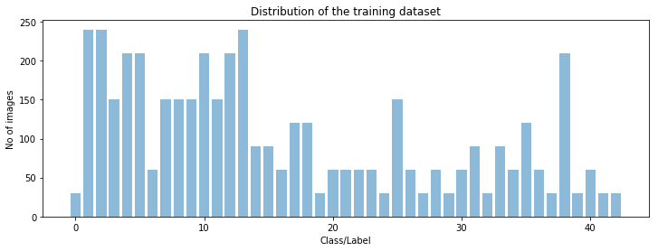

```python
# dist of validation set
show_dist(y_validation)
```

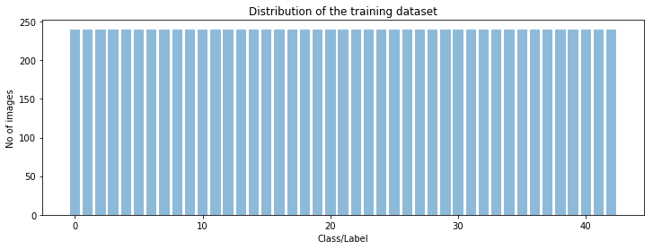

```python
X_validation_extended, y_validation_extended = extend_data(X_validation_gry, y_validation)
show_dist(y_validation_extended)
```

## Step 2: Design and Test a Model Architecture

Design and implement a deep learning model that learns to recognize traffic signs. Train and test your model on the German Traffic Sign Dataset.

The LeNet-5 implementation shown in the classroom at the end of the CNN lesson is a solid starting point. You'll have to change the number of classes and possibly the preprocessing, but aside from that it's plug and play!

With the LeNet-5 solution from the lecture, you should expect a validation set accuracy of about 0.89. To meet specifications, the validation set accuracy will need to be at least 0.93. It is possible to get an even higher accuracy, but 0.93 is the minimum for a successful project submission.

There are various aspects to consider when thinking about this problem:

```
Neural network architecture (is the network over or underfitting?)
Play around preprocessing techniques (normalization, rgb to grayscale, etc)
Number of examples per label (some have more than others).
Generate fake data.
```

# LeNet Architecture

[figure not shown]

Source: Yan LeCun

## Preprocess Data

Shuffle the training data.

You do not need to modify this section.

```python
from sklearn.utils import shuffle

# X_train, y_train = shuffle(X_train, y_train)
X_train_extended, y_train_extended = shuffle(X_train_extended, y_train_extended)
X_validation_extended, y_validation_extended = shuffle(X_validation_extended, y_validation_extended)
```

## Setup TensorFlow

The `EPOCH` and `BATCH_SIZE` values affect the training speed and model accuracy.

You do not need to modify this section.

```python
import tensorflow as tf

EPOCHS = 100
BATCH_SIZE = 128
```

## SOLUTION: Implement LeNet-5

Implement the [LeNet-5](http://yann.lecun.com/exdb/lenet/) neural network architecture.

### Input

The LeNet architecture accepts a 32x32xC image as input, where C is the number of color channels. Since MNIST images are grayscale, C is 1 in this case.

### Architecture

**Layer 1: Convolutional.** The output shape should be 28x28x6.

**Activation.** Your choice of activation function.

**Pooling.** The output shape should be 14x14x6.

**Layer 2: Convolutional.** The output shape should be 10x10x16.

**Activation.** Your choice of activation function.

**Pooling.** The output shape should be 5x5x16.

**Flatten.** Flatten the output shape of the final pooling layer such that it's 1D instead of 3D. The easiest way to do is by using `tf.contrib.layers.flatten`, which is already imported for you.

**Layer 3: Fully Connected.** This should have 120 outputs.

**Activation.** Your choice of activation function.

**Layer 4: Fully Connected.** This should have 84 outputs.

**Activation.** Your choice of activation function.

### Output

```python
from tensorflow.contrib.layers import flatten

def LeNet(x):
    # Arguments used for tf.truncated_normal, randomly defines variables for the weights and biases for each layer
    mu = 0
    sigma = 0.1

    # SOLUTION: Layer 1: Convolutional. Input = 32x32x3. Output = 28x28x6.
    # shape = [kernel_size, kernel_size, input_depth, output_depth]
    # input is 32 by 32 and we want 28 by 28
    # o_ht = (i_ht - filter_ht + 1)/vertical_stride
    # 28 = (32 -f + 1)/1  i.e 28 = 33 - f i.e f = 5 i.e. filter height = 5
    # since input and putput are square the filter width = 5 too
    conv1_W = tf.Variable(tf.truncated_normal(shape=(5, 5, 1, 6), mean = mu, stddev = sigma))
    conv1_b = tf.Variable(tf.zeros(6))
    conv1   = tf.nn.conv2d(x, conv1_W, strides=[1, 1, 1, 1], padding='VALID') + conv1_b

    # SOLUTION: Activation.
    conv1 = tf.nn.relu(conv1)

    # SOLUTION: Pooling. Input = 28x28x6. Output = 14x14x6.
    conv1 = tf.nn.max_pool(conv1, ksize=[1, 2, 2, 1], strides=[1, 2, 2, 1], padding='VALID')

    # SOLUTION: Layer 2: Convolutional. Output = 10x10x16.
    conv2_W = tf.Variable(tf.truncated_normal(shape=(5, 5, 6, 16), mean = mu, stddev = sigma))
    conv2_b = tf.Variable(tf.zeros(16))
    conv2   = tf.nn.conv2d(conv1, conv2_W, strides=[1, 1, 1, 1], padding='VALID') + conv2_b

    # SOLUTION: Activation.
    conv2 = tf.nn.relu(conv2)

    # SOLUTION: Pooling. Input = 10x10x16. Output = 5x5x16.
    conv2 = tf.nn.max_pool(conv2, ksize=[1, 2, 2, 1], strides=[1, 2, 2, 1], padding='VALID')

    # SOLUTION: Flatten. Input = 5x5x16. Output = 400.
    fc0   = flatten(conv2)
    fc0 = tf.nn.dropout(fc0, keep_prob)

    # SOLUTION: Layer 3: Fully Connected. Input = 400. Output = 120.
    fc1_W = tf.Variable(tf.truncated_normal(shape=(400, 120), mean = mu, stddev = sigma))
    fc1_b = tf.Variable(tf.zeros(120))
    fc1   = tf.matmul(fc0, fc1_W) + fc1_b

    # SOLUTION: Activation.
    fc1    = tf.nn.relu(fc1)

    fc1 = tf.nn.dropout(fc1, keep_prob)

    # SOLUTION: Layer 4: Fully Connected. Input = 120. Output = 84.
    fc2_W  = tf.Variable(tf.truncated_normal(shape=(120, 84), mean = mu, stddev = sigma))
    fc2_b  = tf.Variable(tf.zeros(84))
    fc2    = tf.matmul(fc1, fc2_W) + fc2_b

    # SOLUTION: Activation.
    fc2    = tf.nn.relu(fc2)

    # SOLUTION: Layer 5: Fully Connected. Input = 84. Output = 43.
    fc3_W  = tf.Variable(tf.truncated_normal(shape=(84, 43), mean = mu, stddev = sigma))
    fc3_b  = tf.Variable(tf.zeros(43))
    logits = tf.matmul(fc2, fc3_W) + fc3_b

    return logits
```

```python
tf.reset_default_graph()

x = tf.placeholder(tf.float32, (None, 32, 32, 1))
y = tf.placeholder(tf.int32, (None))
one_hot_y = tf.one_hot(y, 43)
keep_prob = tf.placeholder(tf.float32)
```

## Training Pipeline

You do not need to modify this section.

```python
rate = 0.0009

logits = LeNet(x)
cross_entropy = tf.nn.softmax_cross_entropy_with_logits(labels=one_hot_y, logits=logits)
loss_operation = tf.reduce_mean(cross_entropy)
# print("Loss is ", loss_operation)
optimizer = tf.train.AdamOptimizer(learning_rate = rate)
training_operation = optimizer.minimize(loss_operation)
```

## Model Evaluation

Evaluate how well the loss and accuracy of the model for a given dataset.

You do not need to modify this section.

```python
inference_operation = tf.argmax(logits, 1)
correct_prediction = tf.equal(inference_operation, tf.argmax(one_hot_y, 1))
accuracy_operation = tf.reduce_mean(tf.cast(correct_prediction, tf.float32))
saver = tf.train.Saver()

def evaluate(X_data, y_data):
    num_examples = len(X_data)
    total_accuracy = 0
    total_loss = 0
    inference_data = np.array([])
    sess = tf.get_default_session()
    for offset in range(0, num_examples, BATCH_SIZE):
        batch_x, batch_y = X_data[offset:offset+BATCH_SIZE], y_data[offset:offset+BATCH_SIZE]
#         accuracy = sess.run(accuracy_operation, feed_dict={x: batch_x, y: batch_y, keep_prob: 1.0})
        accuracy, loss, inference = sess.run([accuracy_operation, loss_operation, inference_operation], feed_dict={x: batch_x, y: batch_y, keep_prob: 1.0})
        total_accuracy += (accuracy * len(batch_x))
        total_loss += (loss * len(batch_x))
        inference_data = np.append(inference_data, inference)
    return total_accuracy / num_examples, total_loss / num_examples, inference_data
#     return total_accuracy / num_examples
```

## Train the Model

Run the training data through the training pipeline to train the model.

Before each epoch, shuffle the training set.

After each epoch, measure the loss and accuracy of the validation set.

Save the model after training.

You do not need to modify this section.

```python
import time
def training_model(X_data_train, y_data_train, X_data_validation, y_data_validation, dropout):
    with tf.Session() as sess:
        sess.run(tf.global_variables_initializer())
        num_examples = len(X_data_train)

        print("Training...")
        print()
        for i in range(EPOCHS):
            start_time =  time.time()
    #         X_train, y_train = shuffle(X_train, y_train)
            train_loss_per_epoch = 0
            for offset in range(0, num_examples, BATCH_SIZE):
                end = offset + BATCH_SIZE
                batch_x, batch_y = X_data_train[offset:end], y_data_train[offset:end]
                train, loss = sess.run([training_operation, loss_operation], feed_dict={x: batch_x, y: batch_y, keep_prob: dropout})
                train_loss_per_epoch += (loss * len(batch_x))
#
            print("Train Loss per epoch= {:.3f}".format(train_loss_per_epoch/num_examples))

#             validation_accuracy = evaluate(X_data_validation, y_data_validation)
#             print("EPOCH {} ...".format(i+1))
#             print("Validation Accuracy = {:.3f}".format(validation_accuracy))
#             print()
            validation_accuracy, validation_loss, inference_data = evaluate(X_data_validation, y_data_validation)
            print("EPOCH {} ...".format(i+1))
            print("Validation Accuracy = {:.3f}".format(validation_accuracy))
            print("Validation Loss = {:.3f}".format(validation_loss))
            print("Time Taken = {:.2f} sec".format(time.time() - start_time))
            print()

        saver.save(sess, './lenet')
        print("Model saved")
```

```python
# print("shape ", X_train_extended.shape)
# print("shao ", X_validation_gry.shape)

dropouts = [ 0.5 ]  #, 0.95, 0.9, 0.85, 0.8, 0.75, 0.7, 0.65, 0.6, 0.55, 0.5]
for drp in dropouts:
    print("Dropout is ", drp)
    training_model(X_train_extended, y_train_extended, X_validation_extended, y_validation_extended, drp)
```

```
Dropout is  0.5
Training...

Train Loss per epoch= 4.974
EPOCH 1 ...
Validation Accuracy = 0.025
Validation Loss = 3.761
Time Taken = 5.46 sec

Train Loss per epoch= 3.758
EPOCH 2 ...
Validation Accuracy = 0.027
Validation Loss = 3.759
Time Taken = 5.08 sec

Train Loss per epoch= 3.752
EPOCH 3 ...
Validation Accuracy = 0.022
Validation Loss = 3.761
Time Taken = 5.08 sec

Train Loss per epoch= 3.603
EPOCH 4 ...
Validation Accuracy = 0.174
Validation Loss = 3.390
Time Taken = 5.11 sec

Train Loss per epoch= 2.955
EPOCH 5 ...
Validation Accuracy = 0.359
Validation Loss = 2.397
Time Taken = 5.09 sec

Train Loss per epoch= 2.433
EPOCH 6 ...
Validation Accuracy = 0.455
Validation Loss = 1.876
Time Taken = 5.09 sec

Train Loss per epoch= 1.984
```

[output cut: 549 more lines]

```
Time Taken = 5.07 sec

Train Loss per epoch= 0.311
EPOCH 99 ...
Validation Accuracy = 0.942
Validation Loss = 0.201
Time Taken = 5.08 sec

Train Loss per epoch= 0.304
EPOCH 100 ...
Validation Accuracy = 0.937
Validation Loss = 0.206
Time Taken = 5.08 sec

Model saved
```

## Evaluate the Model

Once you are completely satisfied with your model, evaluate the performance of the model on the test set.

Be sure to only do this once!

If you were to measure the performance of your trained model on the test set, then improve your model, and then measure the performance of your model on the test set again, that would invalidate your test results. You wouldn't get a true measure of how well your model would perform against real data.

You do not need to modify this section.

```python
with tf.Session() as sess:
    saver.restore(sess, tf.train.latest_checkpoint('.'))
    saver = tf.train.import_meta_graph('lenet.meta')
    saver.restore(sess, "./lenet")

    test_accuracy, test_loss, inference_data = evaluate(X_test_gry, y_test)
    print("Test Accuracy = {:.3f}".format(test_accuracy))
    print("Test Loss = {:.3f}".format(test_loss))
    print("inference data ", inference_data)
```

```
Test Accuracy = 0.939
Test Loss = 0.221
inference data  [ 16.   1.  38. ...,  32.   7.  10.]
```

```python
# test_inference_per_class = np.bincount(inference_data)
np.histogram(inference_data, bins=np.arange(42), density=True)
```

```
(array([ 0.00526148,  0.05596301,  0.05811543,  0.03762755,  0.05125957,
         0.05086097,  0.01179847,  0.03117028,  0.04129464,  0.04105548,
         0.05070153,  0.03061224,  0.05436862,  0.0571588 ,  0.0213648 ,
         0.01801658,  0.01283482,  0.02750319,  0.03021365,  0.00558036,
         0.00924745,  0.00502232,  0.00980548,  0.01251594,  0.00605867,
         0.03850446,  0.01323342,  0.00502232,  0.01251594,  0.00765306,
         0.01347258,  0.02335778,  0.00637755,  0.01698023,  0.01036352,
         0.02989477,  0.00972577,  0.00526148,  0.05373087,  0.00725446,
         0.01124043]),
 array([ 0,  1,  2,  3,  4,  5,  6,  7,  8,  9, 10, 11, 12, 13, 14, 15, 16,
        17, 18, 19, 20, 21, 22, 23, 24, 25, 26, 27, 28, 29, 30, 31, 32, 33,
        34, 35, 36, 37, 38, 39, 40, 41]))
```

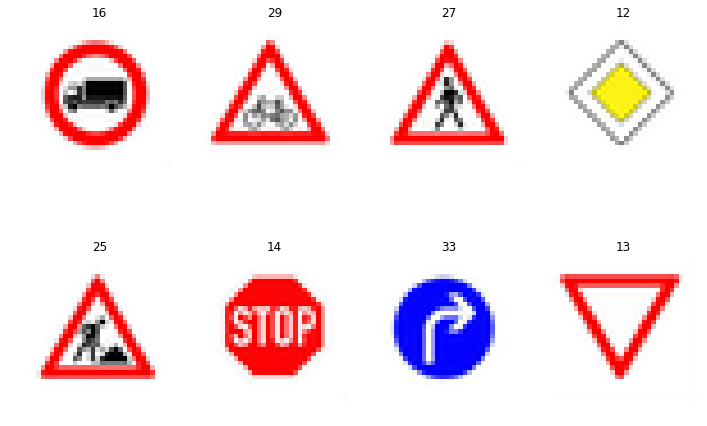

```python
#reading in an image
%matplotlib inline
import glob
import matplotlib.image as mpimg
import matplotlib.pyplot as plt
import cv2
import os
import numpy as np

plt.figure(figsize=(12, 16.5))

outside_images = []
outside_labels = [16, 29, 27, 12, 25, 14, 33, 13]

for i, img in enumerate(sorted(glob.glob('./test_batch1/*.png'))):
#     print(i, dir(img))
    image = cv2.imread(img)
    image = cv2.cvtColor(image, cv2.COLOR_BGR2RGB)
    outside_images.append(image)
    plt.subplot(4, 4, i+1)
    plt.imshow(image)
    plt.title(outside_labels[i])
    plt.axis('off')
plt.show()

# convert to numpy array, the expected input type
outside_images = np.asarray(outside_images)

outside_images_gry = np.sum(outside_images/3, axis=3, keepdims=True)

# print(outside_images_gry[7,:,:,:].min())
# print(outside_images_gry[7,:,:,:].max())
# print(outside_images_gry.shape)

outside_images_gry = outside_images_gry.astype(np.float, copy=False)
```

```python
# Now testing outside images with my model
#     saver.restore(sess, tf.train.latest_checkpoint('.'))
import tensorflow as tf
with tf.Session() as sess:
    saver_outside = tf.train.import_meta_graph('lenet.meta')
    saver_outside.restore(sess, "./lenet")
#     saver.restore(sess, tf.train.latest_checkpoint('.'))

    prediction_accuracy, prediction_loss, inference_output = evaluate(outside_images_gry, outside_labels)
    print("Prediction Accuracy = {:.3f}".format(prediction_accuracy))
    print("Prediction Loss = {:.3f}".format(prediction_loss))
    print("Inferred classes:", inference_output)
```

```
Prediction Accuracy = 0.875
Prediction Loss = 0.540
Inferred classes: [ 16.  29.  18.  12.  25.  14.  33.  13.]
```

```python
### Visualize the softmax probabilities here.
### Feel free to use as many code cells as needed.
import tensorflow as tf
%matplotlib inline
import glob
import matplotlib.image as mpimg
import matplotlib.pyplot as plt
import cv2
import os
import numpy as np

softmax_logits = tf.nn.softmax(logits)
top_k = tf.nn.top_k(softmax_logits, k=3)


with tf.Session() as sess:
#     sess.run(tf.global_variables_initializer())
    saver_outside = tf.train.import_meta_graph('./lenet.meta')
    saver_outside.restore(sess, "./lenet")
    outside_softmax_logits = sess.run(softmax_logits, feed_dict={x: outside_images_gry, keep_prob: 1.0})
    outside_top_k = sess.run(top_k, feed_dict={x: outside_images_gry, keep_prob: 1.0})
```

```python
outside_labels = [16, 29, 27, 12, 25, 14, 33, 13]
indices = outside_top_k.indices
values = outside_top_k.values

for i in range(len(outside_labels)):
    print(i+1, " Actual Label:",outside_labels[i], "TopGuess:-Label:",indices[i][0], "Prob%:",round(100*values[i][0]), "2ndGuess:-Label:",indices[i][1], "Prob%:",round(100*values[i][1],2), "3rdGuess:-Label:",indices[i][2], "Prob%:",round(100*values[i][2],2))
```

```
1  Actual Label: 16 TopGuess:-Label: 16 Prob%: 100.0 2ndGuess:-Label: 9 Prob%: 0.0 3rdGuess:-Label: 10 Prob%: 0.0
2  Actual Label: 29 TopGuess:-Label: 29 Prob%: 99.0 2ndGuess:-Label: 28 Prob%: 1.33 3rdGuess:-Label: 23 Prob%: 0.0
3  Actual Label: 27 TopGuess:-Label: 18 Prob%: 99.0 2ndGuess:-Label: 27 Prob%: 1.34 3rdGuess:-Label: 26 Prob%: 0.01
4  Actual Label: 12 TopGuess:-Label: 12 Prob%: 100.0 2ndGuess:-Label: 25 Prob%: 0.0 3rdGuess:-Label: 40 Prob%: 0.0
5  Actual Label: 25 TopGuess:-Label: 25 Prob%: 100.0 2ndGuess:-Label: 22 Prob%: 0.0 3rdGuess:-Label: 11 Prob%: 0.0
6  Actual Label: 14 TopGuess:-Label: 14 Prob%: 100.0 2ndGuess:-Label: 17 Prob%: 0.0 3rdGuess:-Label: 38 Prob%: 0.0
7  Actual Label: 33 TopGuess:-Label: 33 Prob%: 100.0 2ndGuess:-Label: 17 Prob%: 0.0 3rdGuess:-Label: 35 Prob%: 0.0
8  Actual Label: 13 TopGuess:-Label: 13 Prob%: 100.0 2ndGuess:-Label: 12 Prob%: 0.0 3rdGuess:-Label: 15 Prob%: 0.0
```

As seen above , line 3 , Actual Label is 27 and the model predicts 18 as its top guess and 27 with a probability of 1.3 % ... so all in all a decent predictor seeing that I used the raw images as is without any preprocessing excpet for gray scaling. Point being this model can handle poor image quality and detect with a decent accuracy

[figure not shown]

```python
import tensorflow as tf
%matplotlib inline
import glob
import matplotlib.image as mpimg
import matplotlib.pyplot as plt
import cv2
import os
import numpy as np

n_classes = 43

fig, axs = plt.subplots(8,2, figsize=(9, 19))
axs = axs.ravel()

for i in range(len(outside_softmax_logits)*2):
    if i%2 == 0:
        axs[i].axis('off')
        axs[i].imshow(outside_images[i//2,:,:,:])
    else:
        axs[i].bar(np.arange(n_classes), outside_softmax_logits[(i-1)//2])
        axs[i].set_ylabel('Softmax probability')
```

## Step 4 (Optional): Visualize the Neural Network's State with Test Images

This Section is not required to complete but acts as an additional excersise for understaning the output of a neural network's weights. While neural networks can be a great learning device they are often referred to as a black box. We can understand what the weights of a neural network look like better by plotting their feature maps. After successfully training your neural network you can see what it's feature maps look like by plotting the output of the network's weight layers in response to a test stimuli image. From these plotted feature maps, it's possible to see what characteristics of an image the network finds interesting. For a sign, maybe the inner network feature maps react with high activation to the sign's boundary outline or to the contrast in the sign's painted symbol.

Provided for you below is the function code that allows you to get the visualization output of any tensorflow weight layer you want. The inputs to the function should be a stimuli image, one used during training or a new one you provided, and then the tensorflow variable name that represents the layer's state during the training process, for instance if you wanted to see what the LeNet lab's feature maps looked like for it's second convolutional layer you could enter conv2 as the tf_activation variable.

For an example of what feature map outputs look like, check out NVIDIA's results in their paper End-to-End Deep Learning for Self-Driving Cars in the section Visualization of internal CNN State. NVIDIA was able to show that their network's inner weights had high activations to road boundary lines by comparing feature maps from an image with a clear path to one without. Try experimenting with a similar test to show that your trained network's weights are looking for interesting features, whether it's looking at differences in feature maps from images with or without a sign, or even what feature maps look like in a trained network vs a completely untrained one on the same sign image.

```python
### Visualize your network's feature maps here.
### Feel free to use as many code cells as needed.

# image_input: the test image being fed into the network to produce the feature maps
# tf_activation: should be a tf variable name used during your training procedure that represents the calculated state of a specific weight layer
# activation_min/max: can be used to view the activation contrast in more detail, by default matplot sets min and max to the actual min and max values of the output
# plt_num: used to plot out multiple different weight feature map sets on the same block, just extend the plt number for each new feature map entry

def outputFeatureMap(image_input, tf_activation, activation_min=-1, activation_max=-1 ,plt_num=1):
    # Here make sure to preprocess your image_input in a way your network expects
    # with size, normalization, ect if needed
    # image_input =
    # Note: x should be the same name as your network's tensorflow data placeholder variable
    # If you get an error tf_activation is not defined it may be having trouble accessing the variable from inside a function
    activation = tf_activation.eval(session=sess,feed_dict={x : image_input})
    featuremaps = activation.shape[3]
    plt.figure(plt_num, figsize=(15,15))
    for featuremap in range(featuremaps):
        plt.subplot(6,8, featuremap+1) # sets the number of feature maps to show on each row and column
        plt.title('FeatureMap ' + str(featuremap)) # displays the feature map number
        if activation_min != -1 & activation_max != -1:
            plt.imshow(activation[0,:,:, featuremap], interpolation="nearest", vmin =activation_min, vmax=activation_max, cmap="gray")
        elif activation_max != -1:
            plt.imshow(activation[0,:,:, featuremap], interpolation="nearest", vmax=activation_max, cmap="gray")
        elif activation_min !=-1:
            plt.imshow(activation[0,:,:, featuremap], interpolation="nearest", vmin=activation_min, cmap="gray")
        else:
            plt.imshow(activation[0,:,:, featuremap], interpolation="nearest", cmap="gray")
```